# TDS

2024-06-09

## Introduction

Insurers face a fascinating challenge every day in conducting business; they must sell a product for a certain price that carries an uncertain cost. In tackling this problem, insurers strive to build the best possible predictive risk and pricing models, to distinguish between the low and high-risk customers in the marketplace. The span of statistical models used for this task is wide and varied, from the enduring GLM to the intricate Feed Forward Neural Network (FFNN). Recently, some very promising new models have arrived on the scene, including the Combined Actua rial Neural Network (CANN), and the LocalGLMnet. Both of these models combine GLMs and neural networks to avail of the relative strengths of each architecture. This article will explain how the above four model architectures work, and will test how they perform on a dataset of real-world motor insurance policies. Buckle up!

(Note that the Actuarial Data Science Working Party would like to acknowledge the following authors for their original development and research on these architectures: Mario V. Wüthrich, Michael Merz and Jürg Schelldorfer for CANN; Ronald Richman and Mario V. Wüthrich for LocalGLMnet.)

## Project Setup

To follow along, you can refer to the github repository or download the data we use from there. For the detailed information about package versions and installation guides you can refer to the appendix.

First we set up our project and pull the data:

```r
library(tidyverse)
library(xgboost)
library(reticulate)
library(tensorflow)
library(keras)

slice = dplyr::slice
rename = dplyr::rename

seed = 2
set.seed(seed)

fre_mtpl2_freq = read.csv("freMTPL2freq.csv") %>%

  mutate(  Exposure = pmin(1, Exposure),
           ClaimNb = pmin(15, ClaimNb / Exposure)
  ) %>%
  slice(sample(1:nrow(.),replace = F))
```

A quick look at the data we are going to work with:

```r
summary(fre_mtpl2_freq %>% mutate_if(is.character,as.factor))
```

[output not shown]

We start with just a reminder of a GLM and a feed forward neural network. If you are comfortable with both models feel free to just glance over the formulas in this section and jump to CANN and LocalGLMnet. However if this is your first time hearing about either of the two, you might benefit from a more elaborate introduction than the one below [CasACT](https://www.casact.org/sites/default/files/2021-01/05-Goldburd-Khare-Tevet.pdf) [youtube](https://www.youtube.com/watch?v=ddCO2714W-o&list=PLJ71tqAZr197DkSiGT7DD9dMYxkyZX0ti). Similarly, we skip a detailed analysis of the dataset, as it has been done extensively in the literature [Case Study: French Motor Third-Party Liability Claims](https://papers.ssrn.com/sol3/papers.cfm?abstract_id=3164764).

## GLM

A GLM is a model of the form:

$$\tag{1}
\hat{y} = g(X \beta + \beta_0)$$

where $X \in \mathbb{R}^{n \times p}$ is the matrix of input features, $\beta \in \mathbb{R}^p$ is the vector of coefficients, and $\beta_0 \in \mathbb{R}$ is the intercept.

$$\mathcal{L}(\hat{y}, y) = \sum_{i=1}^{n} (\hat{y}_i - y_i
\log(\hat{y}_i))$$

```r
poisson_deviance = function(y_true,y_pred,keras=F,correction = +10^-7){

  # stopifnot(length(true)!=length(pred),"different input lengths!")

  if(keras){
    # keras:
    # pd = y_pred - y_true * log(y_pred)

  }else{

    pd =  mean((y_pred - y_true - y_true * log((y_pred+correction)/(y_true+correction))))

  }

  return(2 * pd)

}
```

Although in practice this optimization problem might be solved iteratively, there exists a closed form solution to this problem, which - importantly - is not the case in neural nets. There are many packages that allow us to train a glm with a selection of loss functions and optimizers. To fit a basic poisson GLM In R we can use the pre-installed stats package:

```r
glm_model = glm(formula = ClaimNb~.,
                family = poisson,
                data = fre_mtpl2_freq)
```

which is the minimal set of parameters we need.

## Neural Network

In contrast to a GLM, this architecture is very flexible and we can put together n_i of layers with arbitrary number of neurons and activations aiming for a model that is capable of representing non-linearities in our data accurately.

Let us define this feed-forward neural network architecture. Choose the number of layers $k \ge 1$ and $q_{k-1}, q_k \in \mathbb{N}$ neurons in hidden layers. A network layer is a mapping

$$\tag{1}
f_k(x) = W_k x + b_k$$

with $q_k$ hidden neurons in the $k$-th hidden layer given by

$$\tag{*}
h_k = \sigma(f_k(x))$$

with weights

$$\tag{*}
W_k \in \mathbb{R}^{q_k \times q_{k-1}}, \quad b_k \in \mathbb{R}^{q_k}$$

and activation function

$$\tag{*}
\sigma: \mathbb{R} \rightarrow \mathbb{R}$$

A general network architecture with $K$ hidden layers for our Poisson regression problem is then obtained by adding an output layer as follows:

$$\tag{*}
\hat{y} = g(W_{K+1} h_K + b_{K+1})$$

Note that a classical GLM can be obtained as a special case of FFN network, considering depth k=1 we receive a GLM regression function

## CANN

It is essentially a neural network that uses the benchmark GLM’s predictions while learning additional interactions among variables to improve the overall model’s predictive power. There are three common approaches to using a CANN: The GLM element is non-trainable, so the benchmark GLM is always present and only the network part changes. This is the form of CANN included in the analysis to follow. The entire network parameter can be trained, meaning the benchmark GLM can be modified. A trainable credibility weighting can be introduced for the fixed GLM element within the CANN.

for a given claims frequency function xi→ λ(xi), where xi describes the feature information of policy i and vi are the given volumes relating to the exposure in years.

The first term is simply the regression function from our GLM structure, and the second term is that of the NN. The GLM and NN have been combined through simple addition in the output layer. This makes one of the intercepts superfluous. Thus, we typically fix one (β0 of the GLM) and only train w0(K+1). Finally, it is important to add that the GLM and NN need to be defined on the same feature space X. This can require the merging of the feature space of the GLM and network.

While CANN may not generally outperform pure neural networks in minimising the objective loss function, its value for pricing teams lies in uncovering nuanced interactions that can enhance existing GLMs in production.

## LocalGLMnet

In the CANN model, we combined a NN with a GLM by having the models predict in series, and together calculate the prediction for frequency. The LocalGLMnet combines the neural network and GLM in a very different way. We know that the GLM consists of a linear combination of parameters (βs), connected to the response variable through a link function. One set of parameters is used to predict for all records in the dataset. However, what if we could have a different set of parameters for each individual record in the dataset? This way, the different effect of variables on different customers can be captured in a very granular way - there is a custom set of βs for each customer in the dataset. This is what the LocalGLMnet achieves. The innovation of the LocalGLMnet is that a FFNN models the beta parameters for each customer. Then, the prediction for that customer is calculated with those βs in a GLM formula – something we are very familiar with. By retaining the GLM structure in the calculation of predictions in this way, we gain the advantages of a GLM’s explainability. The FFNN’s ability to model complex relationships in the data is still leveraged through the customer-specific calculation of the β parameters.

Also, the interaction effect in a variable can be quantified by calculating the gradient of the parameter’s values along the dimensions of other potentially interacting variables: βj(x).

## Model fitting

We preprocess the data before feeding it to the models. This process is handled by the peproc() function. We choose to normalize the numerical variables and one-hot encode the categoricals. In order to avoid information leakage this function uses only the information from the training dataset. Note - it is possible to randomly select such a train-test split where the test set contains values of categorical variables previously unseen in training.

On a high level this procedure is simple but if you would like to train the models on your machine pulling our github repository is advised as we didn’t show here all of the preprocessing/helper functions used below.

The pseudocode for this section

```
for i in fold number

  selection of training observations
  preprocessing function training
  applying of preprocessing to train and test

  obtain performance of a homogenous model
  train a glm and obtain performance
  train a NN and obtain performance
  train a localGLMnet and obtain performance
  train a CANN and obtain performance

next i
```

## Results Analysis

Functions for generating the charts are also available in the repository. Here we will focus just on the their interpretation.

```r
# poisson loss per cv and model, will add formatting later


rbind(results$losses,
      results$losses %>%
        pivot_longer(cols = !CV) %>%
        group_by(name) %>%
        summarise(mean_poiss = mean(value)) %>%
        arrange(mean_poiss) %>%
        pivot_wider(values_from = mean_poiss,names_from = name) %>%
        mutate(CV = "mean_poiss"))
```

[output not shown]

Gini per model. (we can further split per CV if needed, I will add the table formatting later)

[figure not shown]

```r
lapply(c( "glm","ff_nn","localGLMnet","CANN","homog"),
       function(x){

         MLmetrics::Gini(y_pred = analysis_wide[[x]],y_true = analysis_wide$actual)

         }) %>%


  set_names(c( "glm","ff_nn","localGLMnet","CANN","homog")) %>% unlist() #%>%
  # kable("html", escape = FALSE, col.names = c("p", "distribution", "domain \\(Y\\)", "domain \\(\\mu\\)")) %>%
  # kable_styling(full_width = FALSE, position = "left") %>%
  # column_spec(1, bold = TRUE) %>%
  # column_spec(3:4, width = "3cm") %>%
  # row_spec(0, bold = TRUE, color = "black", background = "lightgrey")
```

[output not shown]

if that’s interesting, we could drill look at lifts for subsets of the data.

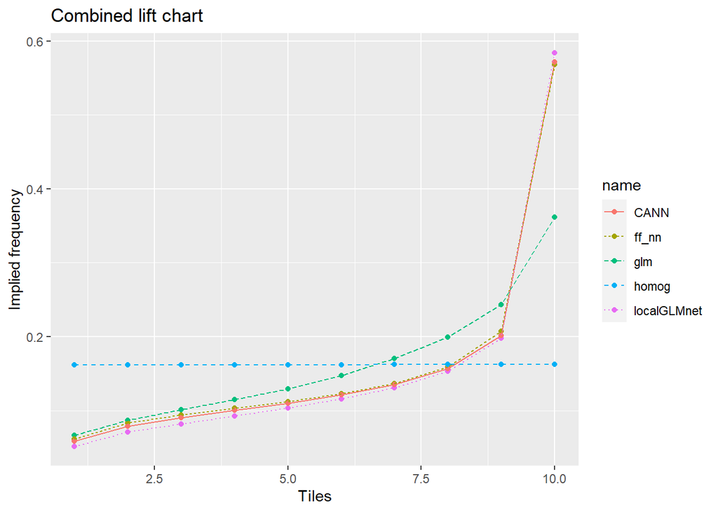

we can select a number of one way charts for different models/variables

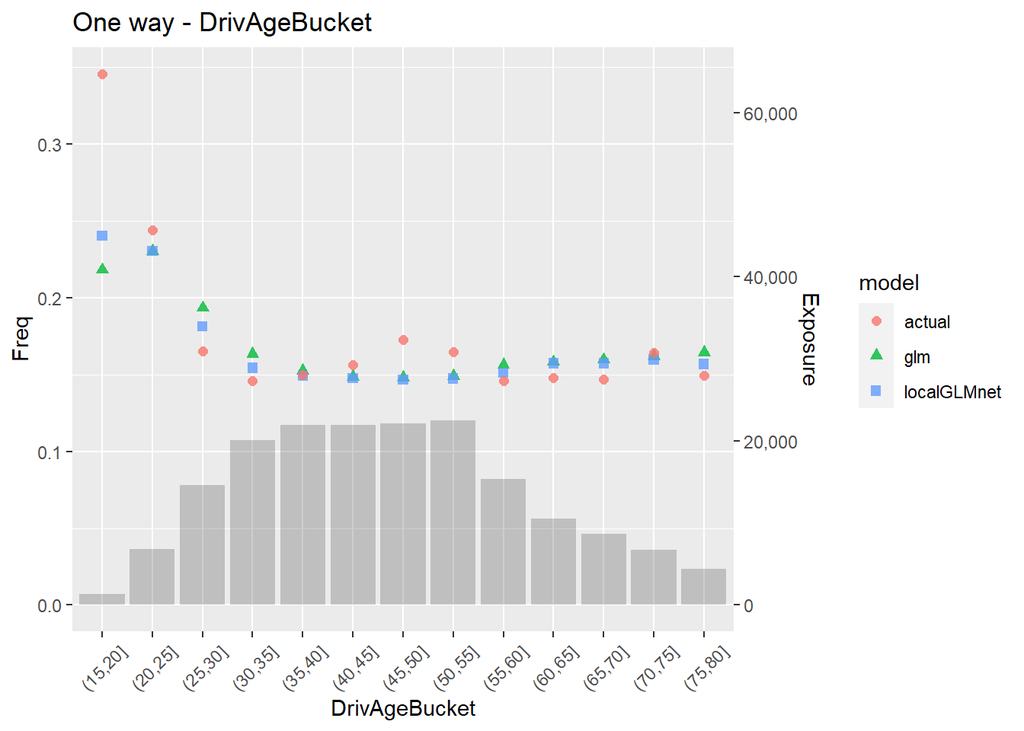

## Appendix

### Packages

other attached packages: mlrMBO_1.1.5.1 smoof_1.6.0.3 checkmate_2.2.0 mlr_2.19.1 ParamHelpers_1.14.1 keras_2.11.1  
tensorflow_2.11.0 reticulate_1.30 xgboost_1.7.5.1 lubridate_1.9.2 forcats_1.0.0 stringr_1.5.0  
dplyr_1.1.2 purrr_1.0.1 readr_2.1.4 tidyr_1.3.0 tibble_3.2.1 ggplot2_3.4.2  
tidyverse_2.0.0

### Using Tensorflow in R

```r
library(reticulate)
library(tensorflow)
library(keras)

use_condaenv(condaenv = "ADSWPNL",required = T) # ADSWP is a py env with tensorflow v 2.7
set_random_seed(seed, disable_gpu = FALSE)
py_module_available("tensorflow")
is_keras_available()

py_config()
tensorflow::tf_version()
```